Journal of Infection 80 (2020) 261–270

[figure not shown]

[figure not shown]

Contents lists available at ScienceDirect

Journal of Infection

journal homepage: www.elsevier.com/locate/jinf

The eﬃcacy of topical agents used in wounds for managing chronic

bioﬁlm infections: A systematic review

S. Schwarzer <sup>a</sup><sup>,</sup><sup>∗</sup>, G.A. James <sup>b</sup>, D. Goeres <sup>b</sup>, T. Bjarnsholt <sup>c</sup><sup>,</sup><sup>d</sup>, K. Vickery <sup>e</sup>, S.L. Percival <sup>f</sup>,

P. Stoodley <sup>g</sup>, G. Schultz <sup>h</sup>, S.O. Jensen <sup>a</sup><sup>,</sup><sup>i</sup>, M. Malone <sup>a</sup><sup>,</sup><sup>i</sup>

a *South* *West* *Sydney* *Limb* *Preservation* *and* *Wound* *Research,* *South* *West* *Sydney* *Local* *Health* *District,* *Sydney,* *Australia*

b *Centre* *for* *Bioﬁlm* *Engineering,* *Montana* *State* *University,* *Bozeman,* *MT,* *United* *States*

c *Department* *of* *Immunology* *and* *Microbiology,* *Costerton* *Bioﬁlm* *Centre,* *University* *of* *Copenhagen,* *Copenhagen,* *Denmark*

d *Department* *of* *Clinical* *Microbiology,* *Copenhagen* *University* *Hospital,* *Copenhagen,* *Denmark*

e *Surgical* *Infection* *Research* *Group,* *Faculty* *of* *Medicine* *and* *Health* *Sciences,* *Macquarie* *University,* *Sydney* *Australia*

f *5D* *Health* *Protection* *Group* *Ltd,* *Centre* *of* *Excellence* *in* *Bioﬁlm* *Science* *(CEBS),* *Liverpool* *Bio-Innovation* *Hub,* *Liverpool* *UK*

g *Departments* *of* *Microbial* *Infection* *and* *Immunity,* *and* *Orthopaedics,* *Ohio* *State* *University,* *Columbus,* *OH,* *United* *States*

h *Department* *of* *Obstetrics* *&* *Gynecology,* *Institute* *for* *Wound* *Research,* *University* *of* *Florida,* *Gainesville,* *FL,* *United* *States*

a r t i c l e

i n f o

*Article* *history:*

Accepted 24 December 2019

Available online 31 December 2019

*Keywords:*

Chronic wound

Infection

Bioﬁlm

Topical agent

s u m m a r y

*Objectives:* Clinicians have increasingly adopted the widespread use of topical agents to manage chronic

wound infections, despite limited data on their effectiveness *in* *vivo* . This study sought to evaluate the

evidence for commonly employed topical agents used in wounds for the purpose of treating chronic in-

fections caused by bioﬁlm.

*Method:* We included *in* *vitro* , animal and human *in* *vivo* studies where topical agents were tested for

their eﬃcacy against bioﬁlms, for use in wound care. For human studies, we only included those which

utilised appropriate identiﬁcation techniques for visualising and conﬁrming the presence of bioﬁlms.

*Result:* A total of 640 articles were identiﬁed, with 43 included after meeting eligibility. *In* *vitro* test-

ing accounted for 90% ( *n* = 39) of all included studies, ﬁve studies using animal models and three hu-

man *in* *vivo* studies. Sixteen different laboratory models were utilised, with the most frequent being the

minimum bioﬁlm eradication concentration (MBEC <sup>TM</sup>) / well plate assay (38%, *n* = 15 of 39). A total of

44 commercially available topical agents were grouped into twelve categories with the most commonly

tested agents being silver, iodine and polyhexamethylene biguanide (PHMB). *In* *vitro* results on eﬃcacy

demonstrated iodine as having the highest mean log10 reductions of all agents (4.81, ±3.14).

*Conclusion:* There is large disparity in the translation of laboratory studies to researchers undertaking

human trials relating to the effectiveness of commercially available topical agents. There is insuﬃcient

human *in* *vivo* evidence to deﬁnitively recommend any commercially available topical agent over another

for the treatment of chronic wound bioﬁlms. The heterogeneity identiﬁed between study designs ( *in* *vitro*

to *in* *vivo* ) further limits the generalisability of results.

Crown Copyright © 2020 Published by Elsevier Ltd on behalf of The British Infection Association. All

rights reserved.

**Introduction**

Bioﬁlms are frequently deﬁned based on *in* *vitro* observations.

Classic deﬁnitions often describe bioﬁlms as; aggregates of mi-

croorganisms embedded in a matrix of extracellular polymeric

substances (EPS). <sup>1–6</sup>*In* *vivo* , bioﬁlms can be attached to host or

foreign body surfaces or exist in ﬂuids adjacent to those surfaces,

∗ Correspondence to: Ingham Institute of Applied Medical Research, 1 Campbell

Street, Liverpool NSW 2170, Australia.

*E-mail* *address:* saskia.schwarzer@health.nsw.gov.au (S. Schwarzer).

or lodged in tissue. <sup>7</sup><sup>,</sup><sup>8</sup>Microbial cells in a bioﬁlm exhibit altered

growth and behaviours which make them highly tolerant towards

antibiotics and host defences. <sup>9–11</sup>This explains why bioﬁlms have

been acknowledged as a growing concern in healthcare. In chronic

wounds they have been implicated as a cause of delayed healing, <sup>12</sup>

and as drivers of chronic and persistent infections. <sup>13</sup><sup>,</sup><sup>14</sup>

Topical antimicrobials and antiseptics (and non-antimicrobial

agents) for treating wound infections have been used in healthcare

for generations, going back to ancient times. <sup>15</sup>A topical application

possess several advantages to systemic therapy including (1) deliv-

ering a high dose of the agent at the local site in varying formula-

https://doi.org/10.1016/j.jinf.2019.12.017

ries; (2) reduced co-lateral toxicity often associated with systemic

therapy, and; (3) an easier administration of treatment by a range

of health professionals and the patient themselves. Non-antibiotic

topical agents may also prove helpful in addressing the increasing

global problem of multidrug-resistant organisms by reducing the

use of antibiotics. <sup>16</sup>

The most commonly used topical agents in wounds today have

traditionally been employed (and their effectiveness tested *in* *vitro* )

for use against rapidly growing planktonic cells (free ﬂoating single

cells) that are responsible for causing acute infections. However, as

the evidence base has increased for the role of bioﬁlms as a cause

of delayed wound healing <sup>12</sup><sup>,</sup><sup>13</sup><sup>,</sup><sup>17</sup><sup>,</sup><sup>18</sup>and as cause of chronic and

persistent infections, <sup>14</sup><sup>,</sup><sup>19</sup><sup>,</sup><sup>20</sup>these same topical agents have been

adopted for use towards managing chronic wounds complicated by

bioﬁlm. The inherent problem with this approach has been the lack

of evidence available to clinicians from medical device companies

with reference to the eﬃcacy of their topical agent in an appro-

priately designed laboratory model or *in* *vivo* study. <sup>21</sup>Malone and

colleagues <sup>21</sup>published a recent commentary on the lack of labo-

ratory standardisation across testing the eﬃcacy of agents against

bioﬁlm. The commentary also highlighted the challenges facing

clinicians when relying solely on *in* *vitro* data, in that many *in* *vitro*

model designs are not necessarily reﬂective, nor representative of a

topical agents intended clinical purpose.

The objective of this systematic review was to collate a compre-

hensive review of available studies ( *in* *vitro* , animal and human *in*

*vivo* ) testing the eﬃcacy of topical agents against bioﬁlms, in the

context of that agent being commonly utilised in wounds.

**Methods**

The systematic review was registered on the PROSPERO

database (CRD42018116905) which adhered to the Preferred Re-

porting Items for Systematic Reviews and Meta-Analysis Protocol

(PRISMA). <sup>22</sup>

*Eligibility*

*Test* *agent*

For the purpose of our review we deﬁned a test agent as being

an; antiseptic, antimicrobial or surfactant suitable for application

on human skin and soft tissue through deﬁned delivery vehicles;

gels, ointments, creams, pastes, water or alcohol-based solutions,

powder and dressing materials (bio-absorbable/biodegradable). To

ensure relevance for clinicians, the decision was made to only

include commercially available agents used in wound care. The

topical agent must have also held regulatory approval for use as

a medical device (wound dressing) from an appropriate regula-

tory body ( *i.e.* Food and Drug Administration [FDA] or Conformite

Europeene [CE] mark). This excludes studies testing extractions

from dressings, rather than the available product. We did not in-

clude novel agents, peptides, compounds or any other agents used

outside of their intended application ( *i.e.* , off-label use).

*Inclusion* *and* *exclusion* *criteria*

We included *in* *vitro* , animal ( *ex* *vivo* and *in* *vivo* ) and human *in*

*vivo* studies. For studies to be considered eligible, the topical agent

being tested must have been a product that was commercially

available for use in human wounds. Study designs which sought

to assess the effectiveness of topical agent/s in eradication or re-

duction of established bioﬁlms were included. We did not include

study designs where a topical agent was tested against the abil-

ity to prevent bioﬁlm formation through its activity against plank-

tonic phase bacteria (bioﬁlm forming strains). Studies focused on

topical antibiotics or disinfectants were excluded as their routine

use in wounds is not recommended. <sup>23</sup><sup>,</sup><sup>24</sup>For human *in* *vivo* stud-

ies we included randomised and non-randomised controlled trials,

case-control studies, cohort studies, before-and-after studies and

prospective non-controlled studies. We did not include retrospec-

tive studies, case studies or conference abstracts. For human *in* *vivo*

studies all participants must have been over 18 years and treated

with a topical agent for a lower limb wound. This included dia-

betic foot ulcers (DFU), venous leg ulcers (VLU), pressure ulcers

(PU) and non-healing surgical wounds (NHSW). We did not in-

clude burns or other connective tissue, inﬂammatory or blistering

diseases as the pathology of these wounds is vastly different, and

the management strategies have their own unique considerations.

Additionally, only studies that used appropriate visualisation tech-

niques to conﬁrm the presence of bioﬁlm in human tissue were in-

cluded (scanning electron microscopy [SEM], transmission electron

microscopy [TEM], conventional and peptide nucleic acid ﬂuores-

cent *in* *situ* hybridisation [PNA-FISH] with confocal laser scanning

microscopy [CLSM], light microscopy and transmission).

*Search* *strategy*

A systematic search of the literature was undertaken between

the 26th of November 2018 and 10th of December 2018 using a

pre-deﬁned search mesh (S1). Articles published after the year

2007 were eligible for review, and articles of any language were

included. The Cochrane Library, Pubmed/Medline, EMBASE and

clinical trial registries were systematically searched. All titles

and abstracts were imported into Zotero reference management

software (Zotero 5.0, Fairfax, Virginia, USA). Titles and abstract

were screened independently by two authors (SS & MM).

*Data* *extraction* *and* *quality* *assessment*

Data extraction and the quality of included studies were inde-

pendently assessed by the panel of authors. A data extraction and

grading tool to assess the quality of *in* *vitro* studies and collate the

evidence was created by the authors as there were none publicly

available (S2). The tool is an adaptation of the ‘minimum infor-

mation about a bioﬁlm experiment’ (MIABiE) initiative. <sup>25</sup>No pub-

licly available and accepted bias assessment tool for *in* *vitro* stud-

ies exists. Animal studies were graded using the ARRIVE guidelines

(Animal Research: Reporting of *In* *Vivo* Experiments), and allocated

a score corresponding to the recommendations. <sup>26</sup>Human studies

were graded using the Scottish Intercollegiate Guidelines Network

(SIGN). <sup>27</sup>The extracted data for all models can be viewed in S3.

*Outcomes* *of* *interest*

The primary outcome measure was to collate the overall evi-

dence available on the quality and level of evidence for the effec-

tiveness of topical agents against bioﬁlms in the context of human

wounds. Speciﬁcally, we sought to establish which types of topical

agents had been tested, and in which study designs, in order to

understand where the majority of evidence exists. This may high-

light if there are suitable levels of evidence for any agent/s across a

range of testing methods ( *in* *vitro* to human) and identify any gaps

for future research needs.

For the purpose of this study, we deﬁned effectiveness of a

topical agent in relation to its effects on bioﬁlm; killing mi-

crobes in bioﬁlm, removing/dispersing bioﬁlm and reducing EPS.

Secondary outcomes of interest included; reporting study log re-

ductions (colony forming units measured in millilitre or gram

[cfu/ml/or g]) or other measures of bacterial activity ( *i.e.* quanti-

tative polymerase chain reaction (qPCR), biomass or optical den-

sity) to identify if any topical agents performed better than others

when viewed collectively, and review and assessment of laboratory

and animal model designs and within study variables to provide an

overall quality score. For human *in* *vivo* studies, the evidence level

was assessed, and data extracted to identify if topical agents are

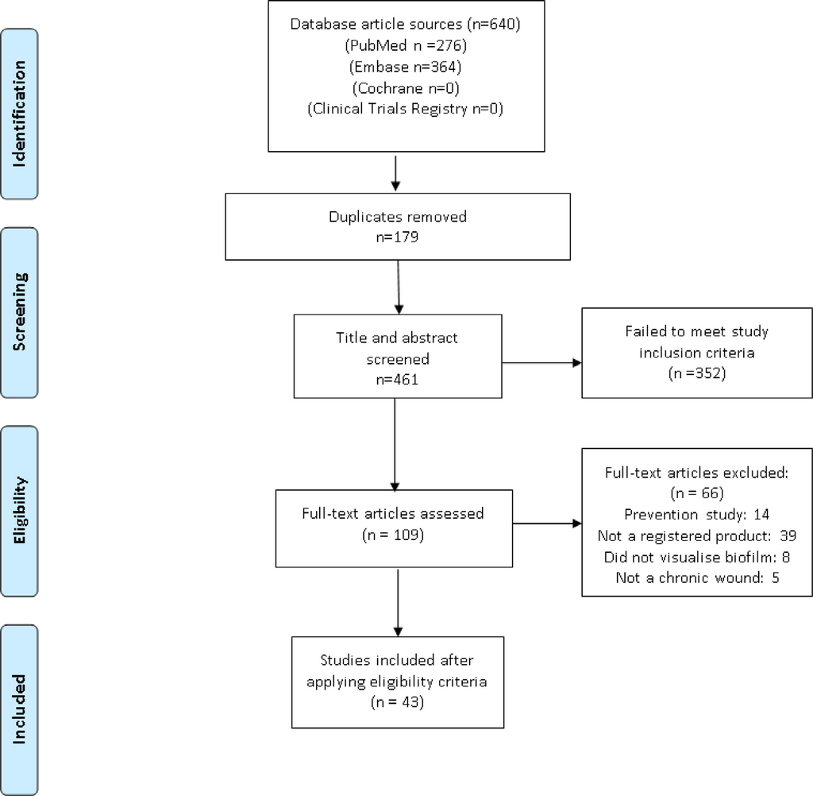

**Fig.** **1.** PRISMA ﬂow diagram mapping out the number of records identiﬁed, included and excluded, and the reasons for exclusions.

effective against wound bioﬁlms, and if their use impacts wound

outcomes.

**Statistics**

A narrative synthesis approach was used to summarise data ex-

tracted from full-text articles. Meta-analysis was not possible due

to the heterogeneity of the data. Bacterial reduction data measured

by cfu/ml/or gram was standardised by log transforming the data,

if not already presented in this manner by the author. Data were

analysed through Statistical Package for Social Sciences Version 24

(SPSS Inc., Chicago, Illinois, USA). For all comparisons and mod-

elling, the level of signiﬁcance was set at *P* *<* 0.05. Data are given

as mean, range and standard deviation ( ±).

**Results**

A total of 640 articles were identiﬁed. Fig. 1 depicts the PRISMA

ﬂowchart of included studies and reasons for study exclusion. Af-

ter removal of duplicates, 461 articles were screened for inclusion.

After screening each articles title and abstract, a further 352 were

excluded for not meeting eligibility criteria. The full text of 109 ar-

ticles were assessed, and a further 66 articles were excluded. In

total, 43 articles (47 studies) were included for review; 39 *in* *vitro*

studies, ﬁve animal studies, and three human *in* *vivo* studies (S3).

Four papers used more than one approach ( *in* *vitro* , animal and hu-

man *in* *vivo* ). The different models that these studies utilised are

shown in Table 1 .

**Formulary** **of** **topical** **agents**

A total of 44 commercially available topical agents were

grouped into twelve categories shown in Table 2 . The most

commonly tested agents were; silver agents ( *n* = 18), tested

and a rabbit ear model. <sup>31</sup><sup>,</sup><sup>40</sup><sup>,</sup><sup>44</sup>Iodine agents ( *n* = 5), tested in

twelve *in* *vitro* models, <sup>31</sup><sup>,</sup><sup>33</sup><sup>,</sup><sup>36</sup><sup>,</sup><sup>38</sup><sup>,</sup><sup>39</sup><sup>,</sup><sup>41</sup><sup>,</sup><sup>45–50</sup>one *in vivo* mouse

model <sup>31</sup>and one human *in vivo* study. <sup>51</sup>Polyhexamethylene

biguanide (PHMB) agents ( *n* = 3) were tested in nine *in* *vitro*

models, <sup>31</sup><sup>,</sup><sup>36</sup><sup>,</sup><sup>39</sup><sup>,</sup><sup>45</sup><sup>,</sup><sup>46</sup><sup>,</sup><sup>48</sup><sup>,</sup><sup>52–54</sup>an *in* *vivo* porcine study, <sup>55</sup>and one hu-

man *in* *vivo* study. <sup>56</sup>

**Table** **1**

Represents all Bioﬁlm Models used in included studies.

Model

Number of times used and study reference:

In Vitro Models

96 Well plate/MBEC/Well

plate/microtiter

15

Klasinc et al. 2018; Halstead et al. 2017; Ortega-Pena et al. 2017; Percival et al. 2017; Zamora et al. 2017; Bowler

et al. 2016; Desroche et al. 2016; Bjarnsholt et al. 2015; Halstead et al. 2015; Larko et al. 2015; Cooper et al.

2014; Gawande et al. 2014; Lu et al. 2014; Brackman et al. 2013; Kostenko et al. 2010

CDC reactor

6

Johani et al. 2018; Tahir et al. 2018; Hoekstra et al. 2017; Percival et al. 2017; Touzel et al. 2016; Ngo et al. 2012

Filter

3

Percival et al. 2017; Bjarnsholt et al. 2015; Wu et al. 2015

Continuous Flow Tube reactor

1

Sauer et al. 2009

Flatbed perfusion

2

(a)Thorn et al. 2009; (b) Thorn et al. 2009

Drip ﬂow reactor/Colony DFR

2

Bourdillon et al. 2017; Fitzgerald et al. 2017

Colony Bioﬁlm Model

1

Fitzgerald et al. 2017

Porcine Explant

5

Johani et al. 2018; Yang et al. 2018; Yang et al. 2017; Phillips et al. 2015; Phillips et al. 2013

Glass chamber slide

2

Klasinc et al. 2018; Percival et al. 2008

Filter disc

2

Parsons et al. 2016; Banerjee et al. 2014

Polystyrene plate

1

Day et al. 2017

Microscope slide

1

Vestby and Nesse 2015

Semi-solid

1

Crone et al. 2015

Ampule

1

Said et al. 2014

Constant depth ﬁlm fermenter

1

Hill et al. 2010

Agar plate (gauze implanted)

4

Kalan et al. 2017; Bowler et al. 2016; Parsons et al. 2016; Seth et al. 2014

Animal Model

Rabbit Ear

1

Park et al. 2016

Porcine

1

Davis et al. 2017

Mouse

1

Fitzgerald et al. 2017; Gawande et al. 2014

Human

Venous Leg ulcer

1

Borges et al. 2018

Diabetic Foot Ulcer

2

Johani et al. 2018; Malone et al. 2017

**Table** **2**

Topical agents identiﬁed by generic agent and brand.

Agent

Brand (or generic ingredient if un-branded)

Vehicle/s of delivery

Silver

Acticoat <sup>TM</sup>, Silverlon®, Aquacel® Ag, Aquacel® Ag Extra <sup>TM</sup>,

Silvercel <sup>TM</sup>, Polymem® silver, GranuFoam Silver <sup>TM</sup>(VAC dressing),

Promogran Prisma <sup>TM</sup>, Urgoclean Ag, Atruman® Ag, Mepilex® Ag,

Tegaderm® Ag, Askina® Calgitrol, Actisorb silver <sup>TM</sup>, Biatain® Ag,

Silvasorb®, Therabond®, Exsalt®

Polyurethane dressing, woven nylon, hydroﬁber,

non-woven pad, granufoam, alginate, poly-absorbent

ﬁbres, ointment coated tulle, foam, silicone dressing,

alginate matrix, gel, ag oxysalt

Honey

Manuka Honey UMF <sup>TM</sup>, Medihoney®, Surgihoney <sup>TM</sup>, l -Mesitran®

Ointment, gel

Iodine

Cadexomer Iodosorb <sup>TM</sup>, Iodoﬂex <sup>TM</sup>, Inadine <sup>TM</sup>, Isobetadine®,

Braunol®

Solution, hydrogel, ointment, knitted viscose ﬁbres

Polyhexamethylene Biguanide

(PHMB)

Prontosan®, Curity AMD <sup>TM</sup>

Gel, solution, non-woven sponge

Poloxomer 188

PluroGel®

Gel

Superbabsorbent polymer

Sorbact®, Sorbion®

Acetate fabric dressing pad

Melaleuca oil

Woundaid®

Solution

Hypochlorous / Acetic acid

Acetic Acid, Vashe® Wound Solution, Superoxidised solution,

Microdacyn®, Microcyn®

Solution

Pyridine

Octenidine®, Octenisept®, Octenilin®

Solution

Chlorhexidine

Chlorhexadine, Chlorhexadine and Cetrimide

Solution

Ringers Solution

Ringers Solution

Solution

Electroceutical

Procellera

Single layer of embedded matrix of moisture-activated

microcell batteries

In vitro *studies*

*In* *vitro* testing accounted for 90% ( *n* = 39) of all included stud-

six studies employing two or more bioﬁlm models. <sup>32</sup><sup>,</sup><sup>34</sup><sup>,</sup><sup>48</sup><sup>,</sup><sup>52</sup><sup>,</sup><sup>57</sup><sup>,</sup><sup>58</sup>

Sixteen different laboratory models were utilised, with the most

frequent being the minimum bioﬁlm eradication concentration

(MBEC <sup>TM</sup>) / well plate assay (38%, *n* = 15 of 39). In ten studies (26%,

10 of 39), this assay was used as the sole laboratory model. Mod-

iﬁcations to a laboratory model to better reﬂect a wound environ-

ment ( *i.e.* media to mimic wound ﬂuid, replacing media daily) was

undertaken in over half of studies (56%, 22 of 39).

In total, seventy-eight different bioﬁlm forming bacteria were

used in monospecies models (S4), with the most common species

being *Pseudomonas* *aeruginosa* and *Staphylococcus* *aureus* . Mul-

tispecies models were used in only ﬁve studies (13%, 5 of

39). <sup>34</sup><sup>,</sup><sup>38</sup><sup>,</sup><sup>58</sup><sup>–</sup><sup>60</sup>Twenty-four-hour bioﬁlms (growth duration) were

most commonly used to test topical agents (46%, 18 of 39) followed

by, ≥ seventy-two- hour bioﬁlms (38%, 15 of 39) and forty-eight-

hour bioﬁlms (33%, 13 of 39). The most frequently used method

to conﬁrm bioﬁlm growth pre-testing was CLSM (36%, 14 of 39).

In seventeen studies, bioﬁlm growth pre-testing was not visualised

by any microscopy method, with bioﬁlm growth assumed (43%, 17

of 39). <sup>29</sup><sup>,</sup><sup>36</sup><sup>,</sup><sup>37</sup><sup>,</sup><sup>39</sup><sup>,</sup><sup>40</sup><sup>,</sup><sup>47</sup><sup>,</sup><sup>50</sup><sup>,</sup><sup>52</sup><sup>,</sup><sup>54</sup><sup>,</sup><sup>58</sup><sup>,</sup><sup>59</sup><sup>,</sup><sup>61</sup><sup>–</sup><sup>66</sup>A control or untreated sam-

ple was used in thirty-two studies, with seven studies having no

study control. <sup>28</sup><sup>,</sup><sup>32</sup><sup>,</sup><sup>34</sup><sup>,</sup><sup>37</sup><sup>,</sup><sup>44</sup><sup>,</sup><sup>52</sup><sup>,</sup><sup>63</sup>The most frequent control was an

untreated sample, (51%, 20 of 39) while a positive and negative

control was used in seven studies (18%, 7 of 39). <sup>54</sup><sup>,</sup><sup>64–69</sup>

Bacterial inoculation was reported as cfu/ml in all but four

studies (10%, 4 of 39). <sup>30</sup><sup>,</sup><sup>40</sup><sup>,</sup><sup>50</sup><sup>,</sup><sup>68</sup>The average inoculation amount

was 10 <sup>^</sup><sup>6</sup>cfu/ml ( ±1.09, range: 10 ^ <sup>5</sup>– 10 ^ <sup>8</sup>cfu/ml). The harvest

of bacteria for quantiﬁcation was not reported in six studies (15%,

6 of 39), <sup>34</sup><sup>,</sup><sup>52</sup><sup>,</sup><sup>62</sup><sup>,</sup><sup>63</sup><sup>,</sup><sup>67</sup><sup>,</sup><sup>70</sup>and most studies used different methods

of harvesting; vortex, stomaching, sonication or a combination

**Table** **3**

Data obtained from ≥3 studies on topical agents with the highest performing agents <sup>∗</sup>denoted and subsequent values

(log reduction cfu/ml). Performance data reported from 24-hour exposure time point and combined average reporting

of all exposure timepoints conducted in the study. (a) *In* *vitro* study values and (b) all animal model values. Standard

deviation is calculated if multiple studies for the same agent are included in the review.

(a)

Agent/Dressing Group

Mean log10 cfu/ml reduction

24 h

Combined average

Silver

∗Acticoat 7

4.1 ( ±0.9)

3.73 ( ±2.05)

Aquacel Ag

1.39 ( ±1.29)

1.43 ( ±1.06)

All silver agents

2.18 ( ±1.81)

2.82 ( ±2.13)

Iodine

∗Cadexomer Iodoﬂex

7.33 ( ±1.56)

7.4 ( ±1.3)

Cadexomer Iodosorb

6.68 ( ±3.1)

6.42 ( ±2.67)

All Iodine agents

4.81 ( ±3.14)

5.05 ( ±2.98)

PHMB

∗Prontosan solution

4.76 ( ±2.02)

4.76 ( ±2.16)

All PHMB

3.33 ( ±2.28)

3.47 ( ±2.42)

Poloxomer 188

∗Plurogel

3.71 ( ±2.37)

4.09 ( ±2.38)

(b)

Agent Group

Mean log10 cfu/ml reduction

24 h

Combined mean

Silver

Acticoat 7

0.1

∗Aquacel Ag

1

1

Silvasorb

0.7

0.7

All silver agents

0.85 ( ±0.21)

0.6 ( ±0.45)

Iodine

Cadexomer Iodosorb

4.5

4.5

PHMB

Prontosan solution

2.37 ( ±0.99)

Pyridine

Octenelin

1.66 ( ±1.27)

Octenidine

1.82 ( ±1.16)

All pyridine

1.74 ( ±1)

Hypocholous Acid

Hypochlorous acid

0.67

of methods. Nine studies used a neutralising agent against the

active agent (23%, 9 of 39) ( *i.e.* sodium thioglycolate for sil-

ver). <sup>28</sup><sup>,</sup><sup>29</sup><sup>,</sup><sup>31–33</sup><sup>,</sup><sup>43</sup><sup>,</sup><sup>50</sup><sup>,</sup><sup>57</sup>Eight studies sonicated bacteria, ranging

from 30s to 30min, while some studies did not report the du-

ration (20%, 8 of 39). <sup>28</sup><sup>,</sup><sup>30</sup><sup>,</sup><sup>39</sup><sup>,</sup><sup>46</sup><sup>,</sup><sup>47</sup><sup>,</sup><sup>53</sup><sup>,</sup><sup>60</sup><sup>,</sup><sup>69</sup>Five studies vortexed

bacteria, <sup>29</sup><sup>,</sup><sup>31</sup><sup>,</sup><sup>33</sup><sup>,</sup><sup>38</sup><sup>,</sup><sup>50</sup>and ﬁve studies used both methods (13%,

5 of 39). <sup>36</sup><sup>,</sup><sup>40</sup><sup>,</sup><sup>48</sup><sup>,</sup><sup>57</sup><sup>,</sup><sup>66</sup>Serial dilution and plating was the most

frequent method for quantiﬁcation if reported (59% 23 of 39).

Other methods included surface drop count <sup>68</sup>and the Miles-Mosra

enumeration method, used in one study each. <sup>59</sup>

The exposure time or contact period of test agents in bioﬁlm

models averaged twenty-four hours which occurred as a singular

exposure event, ranging from three seconds to 168h. Two studies

tested multiple exposure events in the same bioﬁlm model by test-

ing the topical solution as part of instillation and dwell with the

use of negative pressure wound therapy. <sup>45</sup><sup>,</sup><sup>46</sup>Following exposure,

the eﬃcacy of topical agents was primarily measured by bacte-

rial viability (cfu) (82%, 32 of 39). Other methods included; optical

density (26%, 10 of 39) and bioﬁlm biomass (20%, 8 of 39). Nine

studies reported multiple methods of bacterial viability (23%, 9 of

39).

Twenty-four studies (61%, 24 of 39) included methods of

“within experiment” repeats ( *i.e.* triplicates). No studies speciﬁcally

reported experimental designs to incorporate independent repeats,

deﬁned as repeated experiments on different days starting the ex-

periment anew, or any reproducibility testing, deﬁned as “between

laboratory” repeats of the same experimental design.

Mean log10 cfu/ml reductions were extracted (where possible)

for *in* *vitro* studies in order to demonstrate any trends in effec-

tiveness between both individual agents, and the categories of

different topical agents ( *i.e.* iodine, silver, honey, surfactants) (S5

and Table 3 ). This was reported for 24 h as the most common

exposure period, as well as the combined average total exposure

time. To provide a more robust measure of effect, only agents that

had been tested in three or more studies were included in the

examination of the highest log reduction values. *In* *vitro* results

on eﬃcacy demonstrated iodine agents as having the highest

mean log10 reduction of all agents (4.81, ±3.14), with the highest

performing individual agent identiﬁed as Cadexomer Iodoﬂex <sup>TM</sup>

(7.33, ±1.56). Silver agents demonstrated mean log10 reduction

of 2.18 ( ±1.81), with the best performing silver Acticoat <sup>TM</sup>7 (4.1,

(4.76 ( ±2.02). Poloxomer 188 was also identiﬁed as an agent type

tested in multiple studies (3.71, ±2.37, Plurogel®).

The aforementioned areas of *in* *vitro* laboratory design were fac-

tored in calculating the mean score of studies using the adapted

MIABiE tool. The mean score across all studies was nine out of

twenty-two ( ± 3.57, range 2–16, Grade of evidence: Low) (S3).

**Animal** **studies** **analysis**

Five *in* *vivo* animal studies ( *n* = 5 of 43, 11%) were identiﬁed

testing the following agents against wound bioﬁlms; silver, <sup>40</sup><sup>,</sup><sup>44</sup>

cadexomer iodine, octenidine dihydrochloride, octenilin, ringers

solution, hypochlorous acid, <sup>31</sup>PHMB <sup>55</sup>and honey. <sup>71</sup>The ARRIVE

guidelines <sup>26</sup>were used to score the methodological quality of each

included study, with the recommendation items scored out of

twenty.

Park and colleagues <sup>71</sup>used a rabbit ear wound bioﬁlm model

to test the eﬃcacy of Manuka honey against a single species (

*S.* *aureus* UAMS-1 *,* clinical strain) three-day mature bioﬁlm. Tissue

punch biopsies were obtained pre and post treatment in addition

to desiccation scabs formed during the treatment period. Manuka

honey was applied to wounds every second day for six days. SEM

and cfu/g tissue were undertaken in the study, but the reporting of

both outcomes against a baseline value was unclear (ARRIVE score

of 9/20).

Davis and colleagues <sup>55</sup>used a porcine model to test PHMB,

octenidine dihydrochloride, octenilin, ringers solution and

hypochlorous acid. Six partial thickness wounds were in-

ﬂicted onto the paravertebral and thoracic area of porcine.

The wounds were inoculated with a bioﬁlm forming methicillin-

resistant *S.* *aureus* laboratory strain (MRSA ATCC 33,593) for a

twenty-four-hour growth period. Conﬁrmation of bioﬁlm growth

was not visualised through microscopy in either control or treat-

ment tissue specimens prior to treatment. The frequency of wound

irrigation via the test agents was performed twice daily. At day

three and six, tissue punch biopsies were obtained identifying that

wounds treated with PHMB exhibited the greatest reduction in

bacterial counts (initial bacterial count = 7.4 log10 cfu/g, ±0.49,

day three = 5.7, log10 cfu/g, ±0 �47, day six = 4.3 log10 cfu/g, ±0.67)

(ARRIVE score of 14/20).

Fitzgerald and colleagues <sup>31</sup>used a mouse model to test the

performance of a silver gel, silver solid dressing and cadexomer

iodine medicated sheet. A bioﬁlm forming multi drug resistant

laboratory strain (MRSA ATCC 33,592) was allowed to form for

twenty-four hours. Wounds were treated once daily for two days.

The results identiﬁed cadexomer iodine achieved *>* 4 log10 cfu/g

of tissue, compared to a silver solid dressing (1 log10 cfu/g tissue)

and silver gel (0.7 log10 cfu/g tissue) (ARRIVE score of 10/20).

Gawande and colleagues <sup>40</sup>used a chronic wound mouse model

to test the eﬃcacy of a silver solid dressing against bioﬁlm. A

surgical excision wound was inﬂicted on the back of mice and

inoculated with an MRSA clinical isolate and allowed to grow for

twenty-four hours. No description was provided as to the ability of

the clinical isolate to form bioﬁlm, nor was a pre-test microscopy

performed to conﬁrm the presence and growth of bioﬁlm. The

results identiﬁed a 0.1 log10 reduction in cfu/g tissue with a

silver solid dressing (pre-treatment cfu/g tissue = 6.9 log10 *versus*

post-treatment = 6.8 log10). (ARRIVE score of 5/20).

Seth and colleagues <sup>44</sup>used a rabbit ear model to test the per-

formance of a silver solid dressing against wild-type seventy-two

hour *P.* *aeruginosa* bioﬁlm. Full thickness dermal wounds were in-

ﬂicted on the ventral surface of twelve rabbits, with two treat-

ments tested per rabbit, consisting of an ‘active control’ of PHMB

dressing, ‘inactive’ alginate dressing and the silver solid dressing.

An *in* *vitro* model was used to examine bioﬁlm growth on gauze

with SEM, however no imaging was undertaken on the rabbit ears.

The results illustrated a two log10 cfu/wound after three applica-

tions of silver solid dressing every two days, compared to both the

active and control dressing. (ARRIVE score of 11/20).

The mean log10 cfu/g reductions from the ﬁve studies were

extracted where possible and are shown in Table 3 b. The ani-

mal data showed an overall trend of agents demonstrating lower

eﬃcacy against bioﬁlm compared to the *in* *vitro* results. Iodine

demonstrated the highest log10 reductions, (4.5 log10 Cadexomer

Iodosorb <sup>TM</sup>) followed by PHMB (2.37, ±0.99 log10 reduction, Pron-

tosan® solution), Pyridine (1.82, ±1 log10 reduction, Octenidine®

solution) and Hypochlorous Acid (0.67 log10 reductions). The total

(S3)

**Human** **studies** **analysis**

A total of three human studies ( *n* = 3 of 43, 7%) were identiﬁed

which included ﬁfty-four participants with DFU or VLUs. Only

three topical agents were tested; iodine ointment (Cadexomer

Iodosorb <sup>TM</sup>), <sup>51</sup>a surfactant wound irrigation with melaleuca oil <sup>48</sup>

(WoundAid®) and a PHMB surfactant wound irrigator (Pron-

tosan®). <sup>56</sup>The studies were graded using the SIGN classiﬁcation

system <sup>27</sup>as level 2, grade of recommendation Level D. Two of the

studies were a proof of concept methodology with small sample

sizes, and one was a randomised controlled trial. All three studies

did not incorporate any analysis past that of microbiological

outcomes. All studies withheld topical antimicrobial or antibiotic

treatment for at least one week prior to enrolment, obtained

pre-and-post tissue specimens and used appropriate microscopy

methods to conﬁrm the presence of bioﬁlm within wounds.

Borges et al. <sup>56</sup>employed a randomised control trial design

to compare a one-off (one-minute exposure) application of either

saline (control) or surfactant wound irrigation with PHMB in VLUs.

Tissue punch biopsies were taken pre and post treatment to deter-

mine cfu/g tissue and the presence of bioﬁlm was conﬁrmed with

TEM. TEM demonstrated bacterial bioﬁlm in all wounds after treat-

ment with both saline and PHMB. There was no reported differ-

ence in post-treatment cfu/g tissue between groups (saline = 3.77

log10 cfu/g tissue *versus* PHMB = 3.67 log10 cfu/g tissue).

Malone et al. <sup>51</sup>undertook a proof of concept design with seven-

teen participants to analyse the effect of cadexomer iodine applied

to chronic DFUs every two days, for a total of seven days. The pres-

ence of bioﬁlm was conﬁrmed with SEM and PNA-FISH with CLSM,

and any reductions in the total microbial loads were determined

using qPCR of the 16S ribosomal rRNA gene. Most participants (11

of tissue *versus* 4.5 log10 16S copies/mg of tissue).

Johani et al. <sup>48</sup>undertook an *in* *vitro* to *in* *vivo* study designed to

examine clinically relevant exposure times of topical wound solu-

tions in respect to chronic wound bioﬁlm in DFUs. In the human *in*

*vivo* study, ten participants had a topical agent (surfactant solution

with melaleuca oil) applied daily for ﬁfteen minutes. Pre-and post-

tissue punch biopsies were obtained, and qPCR used to determine

the total microbial load. The presence of bioﬁlm was conﬁrmed in

all ten participants using SEM and PNA-FISH with CLSM. No change

in total microbial load was detected after seven days of treatment

(4.9 log10 16S copies/mg tissue *versus* 4.8 log10 16S copies/mg of

tissue), and *P.* *aeruginosa* and *S.* *aureus* abundance increased with

use.

**Discussion**

This review presents a detailed analysis of commercially avail-

able topical agents that have been tested for use in the manage-

ment of chronic wound bioﬁlms, encompassing *in* *vitro* , animal and

human *in* *vivo* data. To the best of our knowledge, this is the ﬁrst

review of its kind. The scoring/grading systems utilised assist to

determine the quality of the overall evidence, and collaterally serve

to highlight the gaps within the current evidence.

*Summary* *of* *key* *ﬁndings*

In total, we identiﬁed 640 articles from our search criteria of

which 531 failed to meet study inclusion criteria, or were dupli-

cates. Of the 109 articles that proceeded to full review, sixty-six

further articles were excluded (S3). This was due to; lack of appro-

priate visualisation techniques to conﬁrm the presence of bioﬁlm

from human tissue samples, the use of the topical agent/s not in

the context of chronic wounds or the topical agent/s were tested in

a model designed for bioﬁlm prevention, rather than eradication.

Of the forty-three studies that were included in the ﬁnal analysis,

*in* *vitro* testing accounted for 90% ( *n* = 39 of 43 studies) of all in-

cluded studies, and only three (7%) eligible human studies were

identiﬁed. This analysis clearly identiﬁes a large disparity in the

translation of laboratory studies to researchers undertaking human

trials.

When analysing the thirty-nine included *in* *vitro* studies, a

standardised methodological approach to bioﬁlm testing was

not observed. Sixteen different bioﬁlm models were used with

signiﬁcant variations between test parameters such as; choices of

different bacterial strain or isolate ( *n* = 78), bioﬁlm growth time

(24h to 168h), starting log densities, agent exposure duration (3s

to 168h) and adaptions to *in* *vitro* models to more closely resemble

a wound environment ( *n* = 22 of 39, 56%). Thus, the signiﬁcant

variants identiﬁed in methodological designs limited the overall

analysis and ability to compare the eﬃcacy and outcomes between

agents. In an attempt to circumvent the loss of data, the eﬃcacy

of topical agents *in* *vitro* on bacterial viability was analysed us-

ing the most widely reported quantiﬁcation value (cfu), and by

referencing the bacterial viability by exposure time endpoints

for all agents (24-hours and total combined exposure times). As

variations were consistently different across all studies, the results

may not be truly indicative of an individual product, but can serve

to demonstrate a trend in the overall data.

*Gaps/limitations* *within* *the* *current* *body* *of* *research*

*In* *vitro*

High throughput rapid screening *in* *vitro* models are an im-

portant tool in assessing the potential eﬃcacy and safety of

therapeutic drugs in many branches of medicine, and are often

required before moving into animal testing. <sup>72</sup>Likewise, *in* *vitro*

bioﬁlm testing provides a useful screening tool to review a test

agent’s antibioﬁlm eﬃcacy rapidly and with minimal cost. <sup>18</sup><sup>,</sup><sup>73</sup><sup>,</sup><sup>74</sup>

However like any system, *in* *vitro* screening only has value if

it is reproducible, has low user and situational variability, and

most importantly has good predictive value. Unfortunately, as this

review demonstrates, a standardised methodological approach of

bioﬁlm models for testing topical agents is not common, which

leads to large disparities between testing conditions and limits

meaningful analysis. A recent meta-analysis of antimicrobial ef-

ﬁcacy against bioﬁlms in *in* *vitro* studies found that the choice

of experimental model and method has the greatest inﬂuence on

outcome. <sup>75</sup>The bulk of studies included in this review reported

a positive outcome for the agent they were testing, which raises

questions about model choice and expected outcomes.

Two common themes of *in* *vitro* testing which are related,

but not necessarily dependent issues are: (1) the robustness of

standardised *in* *vitro* methods in terms of repeatability and re-

producibility, and; (2) how well the *in* *vitro* method recapitulates

*in* *vivo* conditions. The ultimate goal is to harmonise these two

factors. A question still open for debate is are *in* *vitro* experiments

so removed from real life conditions as to be irrelevant? <sup>73</sup>Con-

versely, if a product is shown to have poor eﬃcacy *in* *vitro* , is

there any merit in moving forward with a costly animal or clinical

study?

*Measure* *of* *eﬃcacy*

Do log reductions (reported as cfu/ml) for *in* *vitro* tests need

to be more stringent to account for the variability that exists once

a product or agent is tested in an animal model or beyond? Log

reduction is a method that enables statistical evaluation of the data

including determining sources of variability once the stakeholders

agree upon a standard method for evaluating wound care products.

The variability associated with the method can then be used to

calculate the Type I and Type II error rates which are useful for

regulatory decision making. <sup>76</sup>

A major limitation of log reduction as the measure of eﬃcacy

for medical products and devices is that it has no direct correla-

tion to clinical settings. If translational data is the goal, then how

is a clinician to interpret a log reduction value of 3, for instance,

when treating a patient? As an industry there is a need to de-

velop a better correlation coeﬃcient, or perhaps a new interpre-

tation of the log reduction that relates *in* *vitro* and clinical data in

a more practical way. If the use of cfu/ml log reduction is adopted

as the consensus measure, there should also be an established ref-

erence reduction amount. A six-log reduction has been suggested

by the Environmental Protection Agency (EPA) as demonstrating

good eﬃcacy for high-level disinfectants against bioﬁlms on hard

non-porous surfaces with a CDC reactor model, <sup>77–79</sup>but no speciﬁc

clinical guidelines for wound care products exists. However, there

is also the argument that a topical agent should demonstrate com-

plete eradication in a simple model such as MBEC, to ensure clin-

ical eﬃcacy in the more challenging setting of a human wound. <sup>21</sup>

To further complicate the ability of researchers and clinicians to

compare the eﬃcacy of agents by a standardised method, some

studies have only reported eﬃcacy outcomes using alternate meth-

ods such as bioﬁlm biomass <sup>69</sup>and optical density 600 . <sup>54</sup><sup>,</sup><sup>63</sup><sup>,</sup><sup>64</sup><sup>,</sup><sup>69</sup>

This makes comparison of agents impossible and supports the

requirement of consensus regarding a standardised approach to

reporting eﬃcacy.

*Bacteria*

A plethora of different bacterial strains were identiﬁed in the

included studies ( *n* = 78). With this in mind, how do researchers

decide on which bacterial strain/s to use? And which provides a

closer relevance to microorganisms from human wounds? In gen-

eral, the reporting of reasoning and selection of bacterial strains

was poor. As an example, in the studies that used clinical bacte-

rial strains, most did not perform testing to determine if it was a

bioﬁlm forming strain, nor were comparisons made with a simi-

lar laboratory strain. In some instances, bacterial strains were used

from other areas of human disease, such as the laboratory strain

*P.* *aeruginosa* (ATCC 9027) isolated from an outer ear infection, <sup>31</sup>or

*S.* *aureus* (NCTCC 8325) isolated from a corneal ulcer. <sup>29</sup><sup>,</sup><sup>41</sup><sup>,</sup><sup>58</sup><sup>,</sup><sup>69</sup>The

use of a validated reference strain would increase reproducibility

and the ability to compare eﬃcacy results. The bacterial inocula-

tion quantity ranged from 10 ^ <sup>5</sup>to 10 ^ <sup>8</sup>cfu/ml, with some studies

re-inoculating the model at intervals. The majority (87%, 34 of 39)

of models used a single species design. This is not clinically repre-

sentative of *in* *vivo* ﬁndings. <sup>80–82</sup>A starting inoculum should be of

a meaningful log quantity to ensure an appropriate growth that is

not immediately eradicated. <sup>83–86</sup>

The duration of bacterial growth of the studies included in

this systematic review ranged from 24 to 168 h. Wolcott and col-

leagues <sup>87</sup>demonstrated that bioﬁlms are more susceptible when

immature, and that bioﬁlm maturity is impacted by both species

selection and model design. Phillips et al. <sup>46</sup>also demonstrated that

cultures of *P.* *aeruginosa* or *S.* *aureus* required at least three days

(72 h) of growth at 37 °C to develop bioﬁlm communities that were

tolerant to exposure to 0.5% bleach for ten-minutes or twenty-four

hours of exposure to 50x MIC of gentamycin. <sup>88</sup>Conversely, Caste-

nada et al. <sup>49</sup>demonstrated in orthopaedic bioﬁlm infections, that

a twenty-four-hour 96-well plate model might overestimate the

amount of antimicrobial required, as the MBEC was lower when

exposure time was increased.

*Substrate*

Bioﬁlms grown on different substrates ( *e.g.* , inert plastic or

metal compared to biological substrates like collagen) usually de-

velop signiﬁcantly different sensitivities to antibiotics and antisep-

tics. <sup>88</sup><sup>,</sup><sup>89</sup>It is challenging to replicate the multi-cellular topography

found clinically within an *in* *vivo* model <sup>73</sup>, although researchers

have created models and made alterations, such as the use of an

*ex-vivo* porcine model <sup>39</sup><sup>,</sup><sup>46</sup><sup>,</sup><sup>48</sup><sup>,</sup><sup>62</sup><sup>,</sup><sup>88</sup>or through the addition of col-

lagen. <sup>66</sup>This does not mean that data generated using inert syn-

thetic substrates is irrelevant or useless, but readers and clinicians

should be aware that the substrate on which a bioﬁlm is grown

can inﬂuence the effects of antibiotics and antiseptics on mature

bioﬁlm communities. An *in* *vitro* bioﬁlm is also characterised by

attachment to a surface, a factor that is not representative of *in*

*vivo* or *ex* *vivo* ﬁndings. <sup>73</sup>

The addition of wound exudate or ﬂow to a model can in-

crease the clinical relevance, however justiﬁcation, reasoning and

reporting should be clear. The addition of nutrients changes the

way bacterial cells grow, and therefore the use of more represen-

tative media should be considered. <sup>73</sup>This review identiﬁed a vari-

ety of model modiﬁcations. A continuous tube ﬂow reactor <sup>90</sup>was

used in one study, a model which is not clinically representative or

reﬂective of a chronic wound. CDC reactor or colony drip ﬂow re-

actor models had varied exudate levels ranging from 11.7 ml/min <sup>30</sup>

to 125 ml over 24 h <sup>33</sup>, to 40 ml/h, which included negative pressure

wound models. <sup>45</sup>

The strict inclusion and exclusion criteria applied to this review

were considered necessary to ensure the clinical relevance. The

decision to exclude *in* *vitro* bioﬁlm prevention studies is supported

by the general consensus that topical agents and antimicro-

bials should not be used prophylactically, and also supported

by the knowledge that clinicians do not know which wounds

may become chronic and complex, and potentially require an-

timicrobial use. Fourteen prevention only studies were identiﬁed

and excluded, and nine of the included *in* *vitro* studies included

both prevention and eradication models. <sup>36</sup><sup>,</sup><sup>40</sup><sup>,</sup><sup>43</sup><sup>,</sup><sup>54</sup><sup>,</sup><sup>62</sup><sup>,</sup><sup>63</sup><sup>,</sup><sup>67-70</sup>The

strict bioﬁlm visualisation inclusion criteria applied to human *in*

*vivo* studies, excluded a potential eight studies that may have

included wounds with bioﬁlm. <sup>91–98</sup>While it is known that the

majority of chronic wounds may be affected by bioﬁlm, <sup>12</sup>if a

company is claiming eﬃcacy against bioﬁlm speciﬁcally, the ef-

fect should be demonstrated and conﬁrmed microscopically, (in

addition to microbiological measures) as well as through clinical

outcomes.

In summary, signiﬁcant variation in *in* *vitro* bioﬁlm testing of

commercially available topical agents for use in wounds was iden-

tiﬁed. The modiﬁed MIABiE grading tool, although not validated, is

reﬂective of the information required from a bioﬁlm experiment to

ensure it is good quality, and that it may be independently veri-

the aforementioned need for improvement.

This review and its authors advocate for a consensus or recom-

mendation document that provides speciﬁc guidance. This should

target researchers and companies who are involved in testing

products against bioﬁlm, as well as for consumers and clinicians

to be able to more clearly appraise the evidence, and understand

the results reported. The results of *in* *vitro* testing should not over-

state the outcomes, and clinicians should remember that *in* *vitro*

testing is far removed from clinical reality, and results are not

directly translatable.

*Animal*

As demonstrated by the limited number of studies identi-

ﬁed, <sup>31</sup><sup>,</sup><sup>40</sup><sup>,</sup><sup>44</sup><sup>,</sup><sup>55</sup><sup>,</sup><sup>71</sup>there are scant animal studies, and the identiﬁed

studies had limitations in both reporting and study design. The

ARRIVE guidelines <sup>26</sup>have been used as a grading tool for this

review, and are supported by many journals as publishing re-

quirements. This guideline and checklist primarily serves to guide

researchers to produce good quality research and reporting, to

maximise the availability and utility of the data gained from

the experiment, and to prevent unnecessary animal wastage. For

all agents tested, the combined average exposure time mean

log10 reductions were lower than *in* *vitro* results (silver: ani-

mal = 0.6, ±0.45 *versus* *in* *vitro* = 2.82, ±2.13; iodine: animal = 4.5

*versus* *in* *vitro* = 5.05 ± 2.98; PHMB: animal = 2.37 ± 0.99 *versus* *in*

*vitro* = 3.47 ± 2.42). This review identiﬁed some concerns regarding

study design. Randomisation and allocation of treatment was not

discussed in any of the studies, with only Davis and colleagues <sup>55</sup>

avoiding treatment bias due to all animals receiving the same

topical treatments. Gawande and colleagues <sup>40</sup>introduced the

potential for bias through allocation of treatment following bac-

terial inoculation and the growth period. A sample size or power

calculation was not discussed for any of the included studies,

nor was progression to human testing or generalisability of the

results to human biology reported. Only Davis and colleagues <sup>55</sup>

reported on the choice and reasoning in selection of the animal

model.

*Human*

The small number of human *in* *vivo* studies ( *n* = 3) which in-

cluded a total of ﬁfty-four participants demonstrates the paucity

of clinically relevant bioﬁlm research. Perhaps most importantly, it

highlights that practically no commercially available topical agents

for use in human wounds have evidence for eﬃcacy against wound

bioﬁlms. Malone et al. <sup>51</sup>identiﬁed that cadexomer iodine re-

sulted in a one – two log10 reduction in the total microbial load

of wounds complicated by bioﬁlm, whereas both Johani and col-

leagues, <sup>48</sup>and Borges and colleagues <sup>56</sup>identiﬁed that surfactant

solutions of melaleuca oil or PHMB had little effect on the to-

tal microbial load of wounds complicated by bioﬁlm. The three

studies self-reported proof of concept study designs and therefore

were not clinically representative of the typical duration a topical

agent can be used for, and did not incorporate other management

strategies for wounds, such as sharp debridement. <sup>48</sup><sup>,</sup><sup>51</sup><sup>,</sup><sup>56</sup>A Global

Wound Bioﬁlm Consensus <sup>18</sup>recommends an aggressive step-down

approach to managing chronic wound bioﬁlm, which includes the

use of topical agents, which is not feasible to investigate in a pilot

or single intervention study.

*Limitations* *of* *the* *review*

The major limitation of performing this review was the hetero-

geneity of data which was compounded by the inclusion of three

systems ( *in* *vitro* , animal and human *in* *vivo* studies). This pro-

hibited meta-analysis of the results, which reduced the strength

of the evidence to support any particular product. More than half

of the reviewed papers (65%, 28 of 43) were funded directly by

medical companies, or undertaken by researchers employed by the

product company, and a further ﬁve (12%, 5 of 42) did not com-

ment on conﬂict of interest or funding source. This is crucial in

considering the conﬁdence in results, as there is no assurance for

clinicians that the woundcare company has not simply manipu-

lated and stipulated the test parameters to ensure optimal re-

sults for their product. The fact that three quarters of the identi-

ﬁed studies have a risk of publication bias or may be inﬂuenced

by favourable reporting limits the conﬁdence in the outcome,

and supports a requirement for corroboration by independent

laboratory testing.

The review identiﬁes that the majority of evidence available is

*in* *vitro* (90%), with low quality, and high variability. This ﬁnding

supports increased standardisation of aspects of *in* *vitro* models,

including clear and standardised reporting of design and results,

appropriate bacteria growth durations and clinically relevant agent

exposure periods. While *in* *vitro* testing can improve, the knowl-

edge remains that bacterial transcriptome is different between *in*

*vitro* , animal, and human chronic wounds, and therefore designed

models are not truly reﬂective of the clinical processes. <sup>72</sup>

The surprising lack of *in* *vivo* human studies can be interpreted

as a clearly identiﬁed requirement for further research in general,

and more speciﬁcally, clinically representative treatment periods.

In summary, there is not suﬃcient evidence to deﬁnitively recom-

mend one product over another, and the heterogeneity of study

designs limits any outcome suggestion other than the effect on mi-

crobial load, which thus far has not been demonstrated to have an

effect on wound healing.

**Declaration** **of** **Competing** **Interest**

None.

**Acknowledgments**

Raymond Robinson from Ulster University for reviewing the

manuscript.

**Funding**

This research received no speciﬁc grant from any funding

agency in the public, commercial or not-for-proﬁt sectors.

**Transparency** **declaration**

MM, PS, GS, TB, GJ received a consultancy fee from S&N to un-

dertake work not associated with this study but pertaining to pro-

ducing educational material on bioﬁlms in chronic wounds. MM

received a research grant from Smith and Nephew and Mundi

Pharmaceuticals for studies included in this review. All other

authors have nothing to declare

**Supplementary** **material**

Supplementary material associated with this article can be

found, in the online version, at doi: 10.1016/j.jinf.2019.12.017 .

**References**

1. Wingender J , Neu TR , Flemming HC . What are bacterial extracellular polymeric

substances?. In: Wingender J, Neu T, Flemming HC, editors. *Microbial* *Extracel-*

*lular* *Polymeric* *Substances* . Berlin, Heidelberg: Springer; 1999. p. 1–19 .

2. Costerton JW , Lewandowski Z , Caldwell DE , et al. Microbial bioﬁlms. *Annu* *Rev*

*Microbiol* 1995; **49** :711–45 .

3. Burmolle M , Thomsen TR , Fazli M , et al. Bioﬁlms in chronic infections - a matter

of opportunity - monospecies bioﬁlms in multispecies infections. *FEMS* *Immunol*

*Med* *Microbiol* 2010; **59** :324–36 .

4. Parsek MR , Singh PK . Bacterial bioﬁlms: an emerging link to disease pathogen-

esis. *Annu* *Rev* *Microbiol* 2003; **57** :677–701 .

5. Costerton JW , Irvin RT , Cheng KJ . The bacterial glycocalyx in nature and disease.

*Annu* *Rev* *Microbiol* 1981; **35** :299–324 .

6. Costerton JW , Cheng KJ , Geesey GG , et al. Bacterial bioﬁlms in nature and dis-

ease. *Annu* *Rev* *Microbiol* 1987; **41** :435–64 .

7. Hall-Stoodley L , Costerton JW , Stoodley P . Bacterial bioﬁlms: from the natural

environment to infectious diseases. *Nat* *Rev* *Microbiol* 2004; **2** :95–108 .

8. Bjarnsholt T , Alhede M , Alhede M , et al. The *in* *vivo* bioﬁlm. *Trends* *Microbiol*

2013; **21** :466–74 .

9. Hoiby N , Bjarnsholt T , Givskov M , et al. Antibiotic resistance of bacterial

bioﬁlms. *Int* *J* *Antimicrob* *Agents* 2010; **35** :322–32 .

10. Hengzhuang W , Wu H , Ciofu O , et al. Pharmacokinetics/pharmacodynamics of

colistin and imipenem on mucoid and nonmucoid pseudomonas aeruginosa

bioﬁlms. *Antimicrob* *Agents* *Chemother* 2011; **55** :4469–74 .

11. Bjarnsholt T , Ciofu O , Molin S , et al. Applying insights from bioﬁlm biology to

drug development - can a new approach be developed. *Nat* *Rev* *Drug* *Discov*

2013; **12** :791–808 .

12. Malone M , Bjarnsholt T , McBain AJ , et al. The prevalence of bioﬁlms in chronic

wounds: a systematic review and meta-analysis of published data. *J* *Wound* *Care*

2017; **26** :20–5 .

13. Bjarnsholt T , Kirketerp-Moller K , Jensen PO , et al. Why chronic wounds will not

heal: a novel hypothesis. *Wound* *Repair* *Regen* 2008; **16** :2–10 .

14. James GA , Swogger E , Wolcott R , et al. Bioﬁlms in chronic wounds. *Wound* *Re-*

*pair* *Regen* 2008; **16** :37–44 .

15. Shah JB . The history of wound care. *J* *Am* *Col* *of* *Certif* *Wound* *Spec* 2012; **3** :65–6 .

16. World Health Organization. Antimicrobial resistance. World Health Organiza-

tion.

17. Kalan LR , Brennan MB . The role of the microbiome in nonhealing diabetic

wounds. *Ann* *N* *Y* *Acad* *Sci* 2019; **1435** :79–92 .

18. Schultz G , Bjarnsholt T , James GA , et al. Consensus guidelines for the identiﬁ-

cation and treatment of bioﬁlms in chronic nonhealing wounds. *Wound* *Repair*

*Regen* 2017; **25** :744–57 .

19. Wolcott RD , Rhoads DD , Dowd SE . Bioﬁlms and chronic wound inﬂammation. *J*

*Wound* *Care* 2008; **17** :333–41 .

20. Hoiby N , Bjarnsholt T , Moser C , et al. ESCMID guideline for the diagnosis

and treatment of bioﬁlm infections 2014. *Clin* *Microbiol* *Infect* 2015; **21** (Suppl

1):S1–25 .

21. Malone M , Goeres DM , Gosbell I , et al. Approaches to bioﬁlm-associated in-

fections: the need for standardized and relevant bioﬁlm methods for clinical

applications. *Expert* *Rev* *Anti* *Infect* *Ther* 2017; **15:** :147–56 .

22. Shamseer L , Moher D , Clarke M , et al. Preferred reporting items for systematic

review and meta-analysis protocols (PRISMA-P) 2015: elaboration and explana-

tion. *BMJ* 2015; **350** g7647 .

23. Lipsky BA , Dryden M , Gottrup F , et al. Antimicrobial stewardship in wound

care: a position paper from the British society for antimicrobial chemother-

apy and European wound management association. *J* *Antimicrob* *Chemother*

2016; **71:** :3026–35 .

24. Cowling T, Jones S. *Topical* *Antibiotics* *for* *Infected* *Wounds:* *A* *Review* *of* *the* *Clini-*

*cal* *Effectiveness* *and* *Guidelines* . Ottawa CADTH; 2017. https://www.ncbi.nlm.nih.

gov/books/NBK487400/ .

25. Lourenco A , Coenye T , Goeres DM , et al. Minimum information about a bioﬁlm

experiment (MIABiE): standards for reporting experiments and data on sessile

microbial communities living at interfaces. *Pathog* *Dis* 2014; **70:** :250–6 .

26. Kilkenny C , Browne WJ , Cuthill IC , et al. Improving bioscience research re-

porting: the arrive guidelines for reporting animal research. *PLoS* *Biol* 2010; **8:**

e10 0 0412 .

27. Harbour R , Miller J . A new system for grading recommendations in evidence

based guidelines. *BMJ* 2001; **323:** :334–6 .

28. Kostenko V , Lyczak J , Turner K , et al. Impact of silver-containing wound dress-

ings on bacterial bioﬁlm viability and susceptibility to antibiotics during pro-

longed treatment. *Antimicrob* *Agents* *Chemother* 2010; **54:** :5120–31 .

29. Thorn R , Austin A , Greenman J , et al. *In* *vitro* comparison of antimicrobial activ-

ity of iodine and silver dressings against bioﬁlms. *J* *Wound* *Care* 2009; **18** :343–6 .

30. Ngo Q , Vickery K , Deva A . The effect of topical negative pressure on wound

bioﬁlms using an *in* *vitro* wound model. *Wound* *Repair* *Regen* 2012; **20:** :83–90 .

31. Fitzgerald DJ , Renick PJ , Forrest EC , et al. Cadexomer iodine provides superior

eﬃcacy against bacterial wound bioﬁlms *in* *vitro* and *in* *vivo* . *Wound* *Repair* *Re-*

*gen* 2017; **25:** :13–24 .

32. Bowler P , Parsons D . Combatting wound bioﬁlm and recalcitrance with a novel

anti-bioﬁlm hydroﬁber wound dressing. *Wound* *Med* 2016; **14:** :6–11 .

33. Bourdillon K , Delury C , Cullen B . Bioﬁlms and delayed healing - an *in* *vitro* eval-

uation of silver- and iodine-containing dressings and their effect on bacterial

and human cells. *Int* *Wound* *J* 2017; **14:** :1066–75 .

34. Parsons D , Meredith K , Rowlands VJ , et al. Enhanced performance and mode

of action of a novel antibioﬁlm hydroﬁber® wound dressing. *BioMed* *Res* *Int*

2016; **2016:** :1–14 .

35. Desroche N , Dropet C , Janod P , et al. Antibacterial properties and reduction of

MRSA bioﬁlm with a dressing combining polyabsorbent ﬁbres and a silver ma-

trix. *J* *Wound* *Care* 2016; **25** :577–84 .

36. Brackman G , De Meyer L , Nelis HJ , et al. Bioﬁlm inhibitory and eradicating ac-

tivity of wound care products against staphylococcus aureus and staphylococ-

cus epidermidis bioﬁlms in an *in* *vitro* chronic wound model. *J* *Appl* *Microbiol*

2013; **114:** :1833–42 .

37. Said J , Walker M , Parsons D , et al. An *in* *vitro* test of the eﬃcacy of an an-

ti-bioﬁlm wound dressing. *Int* *J* *Pharm* 2014; **474:** :177–81 .

38. Hill KE , Malic S , McKee R , et al. An *in* *vitro* model of chronic wound bioﬁlms

to test wound dressings and assess antimicrobial susceptibilities. *J* *Antimicrob*

*Chemother* 2010; **65:** :1195–206 .

39. Phillips PL , Yang Q , Davis S , et al. Antimicrobial dressing eﬃcacy against ma-

ture pseudomonas aeruginosa bioﬁlm on porcine skin explants. *Int* *Wound* *J*

2015; **12:** :469–83 .

40. Gawande PV , Clinton AP , LoVetri K , et al. Antibioﬁlm eﬃcacy of dispersinb((r))

wound spray used in combination with a silver wound dressing. *Microbiol* *In-*

*sights* 2014; **7:** :9–13 .

41. Thorn RM , Greenman J . A novel *in* *vitro* ﬂat-bed perfusion bioﬁlm model for

determining the potential antimicrobial eﬃcacy of topical wound treatments. *J*

*Appl* *Microbiol* 2009; **107:** :2070–9 .

42. Percival SL , Bowler P , Woods EJ . Assessing the effect of an antimicrobial wound

dressing on bioﬁlms. *Wound* *Repair* *Regen* 2008; **16:** :52–7 .

43. Kalan LR , Pepin DM , Ul-Haq I , et al. Targeting bioﬁlms of multidrug-resistant

bacteria with silver oxynitrate. *Int* *J* *Antimicrob* *Agents* 2017; **49:** :719–26 .

44. Seth AK , Zhong A , Nguyen KT , et al. Impact of a novel, antimicrobial dressing

on *in* *vivo* , pseudomonas aeruginosa wound bioﬁlm: quantitative comparative

analysis using a rabbit ear model. *Wound* *Repair* *Regen* 2014; **22** :712–19 .

45. Tahir S , Malone M , Hu H , et al. The effect of negative pressure wound ther-

apy with and without instillation on mature bioﬁlms in vitro. *Mater* *(Basel)*

2018; **11** :E811 .

46. Phillips PL , Yang Q , Schultz GS . The effect of negative pressure wound therapy

with periodic instillation using antimicrobial solutions on pseudomonas aerug-

inosa bioﬁlm on porcine skin explants. *Int* *Wound* *J* 2013:48–55 10 Suppl 1 .

47. Hoekstra MJ , Westgate SJ , Mueller S . Povidone-iodine ointment demonstrates *in*

*vitro* eﬃcacy against bioﬁlm formation. *Int* *Wound* *J* 2017; **14:** :172–9 .

48. Johani K , Malone M , Jensen SO , et al. Evaluation of short exposure times of

antimicrobial wound solutions against microbial bioﬁlms: from *in* *vitro* to *in*

*vivo* . *J* *Antimicrob* *Chemother* 2018; **73:** :494–502 .

49. Castaneda P , McLaren A , Tavaziva G , et al. Bioﬁlm antimicrobial suscep-

tibility increases with antimicrobial exposure time. *Clin* *Orthop* *Relat* *Res*

2016; **474:** :1659–64 .

50. Vestby LK , Nesse LL . Wound care antiseptics - performance differences against

staphylococcus aureus in bioﬁlm. *Acta* *Vet* *Scand* 2015; **57** :22 .

51. Malone M , Johani K , Jensen SO , et al. Effect of cadexomer iodine on the micro-

bial load and diversity of chronic non-healing diabetic foot ulcers complicated

by bioﬁlm *in* *vivo* . *J* *Antimicrob* *Chemother* 2017; **72** :2093–101 .

52. Klasinc R , Augustin LA , Below H , et al. Evaluation of three experimental *in* *vitro*

models for the assessment of the mechanical cleansing eﬃcacy of wound irri-

gation solutions. *Int* *Wound* *J* 2018; **15:** :140–7 .

53. Crone S , Garde C , Bjarnsholt T , et al. A novel *in* *vitro* wound bioﬁlm model used

to evaluate low-frequency ultrasonic-assisted wound debridement. *J* *Wound*

*Care* 2015; **64** (24):6–9 72 .

54. Ortega-Pena S , Hidalgo-Gonzalez C , Robson MC , et al. *In* *vitro* microbicidal, an-

ti-bioﬁlm and cytotoxic effects of different commercial antiseptics. *Int* *Wound* *J*

2017; **14** :470–9 .

55. Davis SC , Harding A , Gil J , et al. Effectiveness of a polyhexanide irrigation solu-

tion on methicillin-resistant staphylococcus aureus bioﬁlms in a porcine wound

model. *Int* *Wound* *J* 2017; **14** :937–44 .

56. Borges EL , Frison SS , Honorato-Sampaio K , et al. Effect of polyhexamethylene

biguanide solution on bacterial load and bioﬁlm in venous leg ulcers: a ran-

domized controlled trial. *J* *Wound* *Ostomy* *Cont* *Nurs* 2018; **45** :425–31 .

57. Percival S , Mayer D , Salisbury A . Eﬃcacy of a surfactant-based wound dressing

on bioﬁlm control. *Wound* *Repair* *Regen* 2017; **25** :767–73 .

58. Bjarnsholt T , Alhede M , Jensen PO , et al. Antibioﬁlm properties of acetic acid.

*Adv* *Wound* *Care* *(New* *Rochelle)* 2015; **4:** :363–72 .

59. Touzel RE , Sutton JM , Wand ME . Establishment of a multi-species bioﬁlm model

to evaluate chlorhexidine eﬃcacy. *J* *Hosp* *Infect* 2016; **92** :154–60 .

60. Percival S , Bowler P , Woods E . Assessing the effect of an antimicrobial wound

dressing on bioﬁlms. *Wound* *Repair* *Regen* 2008; **16** :52–7 .

61. Yang Q , Larose C , Della Porta A , et al. A surfactant-based wound dressing

can reduce bacterial bioﬁlms in a porcine skin explant model. *Int* *Wound* *J*

2017; **14** :408–13 .

62. Yang Q , Schultz G , Gibson D . A surfactant-based dressing to treat and prevent

acinetobacter baumannii bioﬁlms. *J* *Burn* *Care* *Res* 2018; **39** :766–70 .

63. Zamora L , Beukelman C , van den Berg A , et al. An insight into

the antibioﬁlm properties of Costa Rican stingless bee honeys. *J* *Wound*

*Care* 2017; **26** :168–77 .

64. Halstead F , Webber M , Oppenheim B . Use of an engineered honey to eradicate

preformed bioﬁlms of important wound pathogens: an *in* *vitro* study. *J* *Wound*

*Care* 2017; **26:** :442–50 .

65. Day A , Alkhalil A , Carney BC , et al. Disruption of bioﬁlms and neutralization of

bacteria using hypochlorous acid solution: an in vivo and in vitro evaluation.

*Adv* *Skin* *Wound* *Care* 2017; **30** :543–51 .

66. Larko E , Persson A , Blom K . Effect of superabsorbent dressings in a 3D

acellular tissue model of pseudomonas aeruginosa bioﬁlm. *J* *Wound* *Care*

2015; **24** (204):6–10 .

67. Halstead FD , Rauf M , Moiemen NS , et al. The antibacterial activity of acetic acid

against bioﬁlm-producing pathogens of relevance to burns patients. *PLoS* *One*

2015; **10** :e0136190 .

68. Cooper R , Jenkins L , Hooper S . Inhibition of bioﬁlms of pseudomonas aeruginosa

by medihoney *in* *vitro* . *J* *Wound* *Care* 2014; **23** :93–6 8-100, 102 passim .

69. Lu J , Turnbull L , Burke CM , et al. Manuka-type honeys can eradicate bioﬁlms

produced by staphylococcus aureus strains with different bioﬁlm-forming abili-

ties. *PeerJ* 2014; **2:** e326. .

70. Wu M , Banerjee J , Ghatak PD , et al. Silver-Zinc redox-coupled electroceutical

wound dressing disrupts bacterial bioﬁlm. *PLoS* *One* 2015; **10** e0119531 .

71. Park E , Long S , Seth A , et al. The use of desiccation to treat

staphylococcus aureus bioﬁlm-infected wounds. *Wound* *Repair* *Regen*

2016; **24:** :394–401 .

72. Cornforth DM , Dees JL , Ibberson CB , et al. Pseudomonas aeruginosa transcrip-

tome during human infection. *Proc* *Natl* *Acad* *Sci* *USA* 2018; **115:** E5125-e34 .

73. Roberts AE , Kragh KN , Bjarnsholt T , et al. The limitations of in vitro experi-

mentation in understanding bioﬁlms and chronic infection. *J* *Mol* *Biol* 2015; **427:**

3646-61 .

74. Lebeaux D , Chauhan A , Rendueles O , et al. From *in* *vitro* to *in* *vivo* models of

bacterial bioﬁlm-related infections. *Pathogens* 2013; **2** :288–356 .

75. Stewart PS , Parker AE . Measuring antimicrobial eﬃcacy against bioﬁlms: a

meta-analysis. *Antimicrob* *Agents* *Chemother* 2019; **63** e0 0 020-19 .

76. Parker AE , Hamilton MA , Tomasino SF . A statistical model for assessing perfor-

mance standards for quantitative and semiquantitative disinfectant test meth-

ods. *J* *AOAC* *Int* 2014; **97** :58–67 .

77. Oﬃce of Pesticide Programs. EPA MLB SOP MB-19: Growing a Bioﬁlm Using

the CDC Bioﬁlm Reactor. US Environmental Protection Agency. https://www.epa.

gov/sites/production/ﬁles/2017- 07/documents/mb- 19- may- 2017.pdf .

78. United States Environmental Protection Agency. Methods and Guidance For

Testing the Eﬃcacy of Antimicrobials Against Bioﬁlm Bacteria on Hard, Non-

Porous Surfaces.United States Environmental Protection Agency. https://www.

epa.gov/pesticides/methods- and- guidance- testing- eﬃcacy- antimicrobials-

against- bioﬁlm- bacteria- hard- non .

79. Oﬃce of Pesticide Programs. EPA MLB SOP MB-20: Single Tube Method for De-

termining the Eﬃcacy of Disinfectants Against Bacterial Bioﬁlm. US Environ-

mental Protection Agency. https://www.epa.gov/sites/production/ﬁles/2017-07/

documents/mb- 20- may- 2017.pdf .

80. Citron DM , Goldstein EJ , Merriam CV , et al. Bacteriology of moderate-to-severe

diabetic foot infections and *in* *vitro* activity of antimicrobial agents. *J* *Clin* *Mi-*

*crobiol* 2007; **45** 2819-28 .

81. Ge Y , MacDonald D , Hait H , et al. Microbiological proﬁle of infected diabetic

foot ulcers. *Diabet* *Med* 2002; **19** :1032–4 .

82. Nelson A , Wright-Hughes A , Backhouse MR , et al. CODIFI (Concordance in dia-

betic foot ulcer infection): a cross-sectional study of wound swab *versus* tissue

sampling in infected diabetic foot ulcers in England. *BMJ* *Open* 2018; **8** :e019437 .

83. Pankey GA , Sabath LD . Clinical relevance of bacteriostatic *versus* bactericidal

mechanisms of action in the treatment of gram-positive bacterial infections.

*Clin* *Infect* *Dis* 2004; **38** :864–70 .

84. MacGowan A , Rogers C , Bowker K . In vitro models, in vivo models, and

pharmacokinetics: what can we learn from in vitro models. *Clin* *Infect* *Dis*

2001; **33** :S214–SS20 .

85. Ferran A , Dupouy V , Toutain PL , et al. Inﬂuence of inoculum size on the selec-

tion of resistant mutants of Escherichia coli in relation to mutant prevention

concentrations of marboﬂoxacin. *Antimicrob* *Agents* *Chemother* 2007; **51** :4163–6 .

86. Firsov AA , Vostrov SN , Kononenko OV , et al. Prediction of the effects of inocu-

lum size on the antimicrobial action of trovaﬂoxacin and ciproﬂoxacin against

staphylococcus aureus and Escherichia coli in an *in* *vitro* dynamic model. *An-*

*timicrob* *Agents* *Chemother* 1999; **43** :498–502 .

87. Wolcott RD , Rumbaugh KP , James G , et al. Bioﬁlm maturity studies indicate

sharp debridement opens a time- dependent therapeutic window. *J* *Wound* *Care*

2010; **19:** :320–8 .

88. Yang Q , Phillips PL , Sampson EM , et al. Development of a novel ex vivo porcine

skin explant model for the assessment of mature bacterial bioﬁlms. *Wound* *Re-*

*pair* *Regen* 2013; **21** :704–14 .

89. Williams DL , Smith SR , Peterson BR , et al. Growth substrate may inﬂuence

bioﬁlm susceptibility to antibiotics. *PLoS* *One* 2019; **14** :e0206774 .

90. Sauer K , Thatcher E , Northey R , et al. Neutral super-oxidised solutions are ef-

fective in killing P. aeruginosa bioﬁlms. *Biofouling* 2009; **25** :45–54 .

91. Metcalf D , Parsons D , Bowler P . Clinical safety and effectiveness evaluation of a

new antimicrobial wound dressing designed to manage exudate, infection and

bioﬁlm. *Int* *Wound* *J* 2017; **14** :203–13 .

92. Harding KG , Szczepkowski M , Mikosinski J , et al. Safety and performance eval-

uation of a next-generation antimicrobial dressing in patients with chronic ve-

nous leg ulcers. *Int* *Wound* *J* 2016; **13** :442–8 .

93. Durante CM , Greco A , Sidoli O , et al. Evaluation of the effectiveness of a poly-

hexanide and propyl betaine-based gel in the treatment of chronic wounds.

*Minerva* *Chir* 2014; **69** :283–92 .

94. Tejaswini SA , Vikram GK . Eﬃcacy of honey dressing versus mechanical de-

bridement in healing of ulcers with bioﬁlms a comparative study. *JKIMSU*

2018; **7** :49–55 .

95. Zolss C , Cech JD . Eﬃcacy of a new multifunctional surfactant-based bioma-

terial dressing with 1% silver sulphadiazine in chronic wounds. *Int* *Wound* *J*

2016; **13** :738–43 .

96. Walker M , Metcalf D , Parsons D , et al. A real-life clinical evaluation of a next–

generation antimicrobial dressing on acute and chronic wounds. *J* *Wound* *Care*

2015; **24** :11–22 .

97. Metcalf D , Parsons D , Bowler P . A next-generation antimicrobial wound dress-

ing: a real-life clinical evaluation in the UK and Ireland. *J* *Wound* *Care*

2016; **25** (132):4–8 .

98. Lenselink E , Andriessen A . A cohort study on the eﬃcacy of a polyhexanide–

containing biocellulose dressing in the treatment of bioﬁlms in wounds. *J*

*Wound* *Care* 2011; **20** :6–9 534 .